### Data Introduction

This data was acquired form FishBase (Froese and Pauley 2000) using the rfishbase package (Boettiger et al., 2012; see data_acquisition.R for data retrieval).

The data set includes the following variables:

- `species`: the scientific name of fish
- `genus`: the scientific genus of fish
- `common_name`: common name used for fish
- `body_shape`**: shape of fish body (elongated, fusiform/normal, eel-like, short and/or deep, other)**
- `habitat`**: area of the ocean that fish typically resides in**
- `depth_range_shallow`**: minimum depth fish is found**
- `depth_range_deep`**: maximum depth fish is found**
- `vulnerability`**: metric for how at risk a fish is to over fishing based on other life history and ecological traits**
- `length`**: total length, fork length, or standard length of fish**
- `trophic_level`**: trophic level that the fish occupies based on position in food web**
- `food_troph`: trophic level that fish’s food source occupies
- `food`**: type of food source fish consumes**
- `family`: the scientific family of fish

*Bold variables are included in the models. A full copy of the codebook is included in the data/raw folder*

#### Habitat Types

This project attempts to predict 8 different habitat types. These habitats are described below to note differences.

1. pelagic: living within several regions of the pelagic zone, through both shallower pelagic-oceanic and deeper bathypelagic
2. pelagic-neritic: relating to upper layers of the ocean on the continental shelf. Waters here are not as deep as the pelagic zone
3. reef-associated: living in association with a coral reef. This habitat is the most diverse, offering an array of food types and shelters
4. demersal: relating to living on or near the ocean floor, whether in the pelagic-neritic, pelagic, or bathypelagic zones
5. benthopelagic: relating specifically to the ocean floor in the pelagic zone, but not at the deepest depths
6. bathydemersal: relating to the ocean floor at depths greater than 200 meters
7. pelagic-oceanic: relating specifically to the upper layers of the open ocean. Food is scarce
8. bathypelagic: relating to deeper layers of the open ocean at the continental slope. Limited sunlight reaches this zone

While there is some possible overlap in these categories, they are kept separate as specifically defined in FishBase. Data has already been pre-processed for you.

#### Data Cleaning

We are going to load the data and only use two categories (demersal - i.e., bottom dwelling species - and reef-associated).

Additionally, we are going to binary encode these values. This means turning them into a 0 and 1.

```r
fish_clean = read_csv(here("discussion", "data", "fish_clean.csv")) %>%
  filter(habitat == "demersal" | habitat == "reef-associated") %>%
  mutate(habitat = case_when(
    habitat == "demersal" ~ 0,
    habitat == "reef-associated" ~ 1,
  )) %>%
  mutate(habitat = as.factor(habitat))
```

### Modeling

Today, we will look at preforming logistic regression on this data set. We will continue to come back to this data set as we learn more models in this section.

#### Training and Testing Data Creation

Here, we will use functions from the `rsample` package within `TidyModels`

```r
data_split = initial_split(fish_clean, prop = .8, strata = habitat) #split data stratified by survived

train = training(data_split) #get training data
test = testing(data_split) #get testing data

head(train)
```

```
## # A tibble: 6 × 11
##   genus  species habitat vulnerability family trophic_level_impute length_impute
##   <chr>  <chr>   <fct>           <dbl> <chr>                 <dbl>         <dbl>
## 1 Abali… Abalis… 0                43.8 Balis…                 3.64         60
## 2 Abali… Abalis… 0                43.8 Balis…                 3.64         60
## 3 Acant… Acanth… 0                34.5 Monac…                 2.09         35
## 4 Acant… Acanth… 0                21.2 Monac…                 2.09         14
## 5 Acant… Acanth… 0                10   Chaen…                 3.43          3.20
## 6 Acant… Acanth… 0                10   Chaen…                 3.43          5.10
## # ℹ 4 more variables: shallow_impute <dbl>, deep_impute <dbl>,
## #   shape_impute <chr>, food_impute <chr>
```

```r
head(test)
```

```
## # A tibble: 6 × 11
##   genus  species habitat vulnerability family trophic_level_impute length_impute
##   <chr>  <chr>   <fct>           <dbl> <chr>                 <dbl>         <dbl>
## 1 Abude… Abudef… 1                28.2 Pomac…                 3.15         17
## 2 Abude… Abudef… 1                35.8 Pomac…                 3.10         30
## 3 Abude… Abudef… 1                32.5 Pomac…                 2.80         16
## 4 Acant… Acanth… 1                50.4 Monac…                 2.09         55
## 5 Acant… Acanth… 1                10   Chaen…                 3.43          1.80
## 6 Acant… Acanth… 1                10   Chaen…                 3.43          4.30
## # ℹ 4 more variables: shallow_impute <dbl>, deep_impute <dbl>,
## #   shape_impute <chr>, food_impute <chr>
```

#### Recipe Creation

After splitting my data, the first step is to create a recipe indicating the formula for the model and any pre-processing steps I want to preform on my data. Here we will use the `recipes` package.

I will be predicting habitat based on trophic level, length, minimum depth, maximum depth, vulnerability, body shape, and food source type. We will be normalizing all numeric predictors

```r
fish_recipe = recipe(habitat ~ shape_impute + food_impute + shallow_impute + deep_impute + vulnerability + length_impute + trophic_level_impute, data = train) %>% #create model recipe
  step_normalize(all_numeric_predictors()) #normalize all numeric predictors
```

#### Model 2: Logistic Regression

```r
?logistic_reg
```

```r
log_model = logistic_reg() %>% #set logistic regression model
  set_engine("glm") %>% #use glm engine
  set_mode("classification") #set classification as mode
```

```r
log_workflow = workflow() %>% #create workflow
  add_model(log_model) %>% #add logisitic regression model
  add_recipe(fish_recipe) #add recipe

log_workflow
```

```
## ══ Workflow ════════════════════════════════════════════════════════════════════
## Preprocessor: Recipe
## Model: logistic_reg()
##
## ── Preprocessor ────────────────────────────────────────────────────────────────
## 1 Recipe Step
##
## • step_normalize()
##
## ── Model ───────────────────────────────────────────────────────────────────────
## Logistic Regression Model Specification (classification)
##
## Computational engine: glm
```

#### Model Fitting

```r
train_fit = fit(log_workflow, train) #fit the boosted tree model to the training set

train_fit
```

```
## ══ Workflow [trained] ══════════════════════════════════════════════════════════
## Preprocessor: Recipe
## Model: logistic_reg()
##
## ── Preprocessor ────────────────────────────────────────────────────────────────
## 1 Recipe Step
##
## • step_normalize()
##
## ── Model ───────────────────────────────────────────────────────────────────────
##
## Call:  stats::glm(formula = ..y ~ ., family = stats::binomial, data = data)
##
## Coefficients:
##                     (Intercept)            shape_imputeelongated
##                         -1.8410                          -0.1215
##   shape_imputefusiform / normal                shape_imputeother
##                          0.6263                          -0.8736
## shape_imputeshort and / or deep                food_imputenekton
##                          0.5521                           0.8576
##               food_imputeothers                food_imputeplants
##                         -0.9930                           1.0304
##           food_imputezoobenthos           food_imputezooplankton
##                          0.7269                           0.9408
##                  shallow_impute                      deep_impute
##                         -0.3581                          -0.5614
##                   vulnerability                    length_impute
##                         -0.4536                           0.2635
##            trophic_level_impute
##                          0.0932
##
## Degrees of Freedom: 18236 Total (i.e. Null);  18222 Residual
## Null Deviance:       23860
## Residual Deviance: 21540     AIC: 21570
```

```r
train_predict = predict(object = train_fit, new_data = train) %>% #predict the training set
  bind_cols(train) #bind training set column to prediction

train_predict2 = predict(object = train_fit, new_data = train, type = "prob") %>% #predict the training set
  bind_cols(train) #bind training set column to prediction
```

```r
test_predict = predict(train_fit, test) %>% #get prediction probabilities for test
  bind_cols(test)  #bind to testing column

test_predict2 = predict(train_fit, test, type ="prob") %>% #get prediction probabilities for test
  bind_cols(test)  #bind to testing column

head(test_predict)
```

```
## # A tibble: 6 × 12
##   .pred_class genus    species habitat vulnerability family trophic_level_impute
##   <fct>       <chr>    <chr>   <fct>           <dbl> <chr>                 <dbl>
## 1 1           Abudefd… Abudef… 1                28.2 Pomac…                 3.15
## 2 0           Abudefd… Abudef… 1                35.8 Pomac…                 3.10
## 3 0           Abudefd… Abudef… 1                32.5 Pomac…                 2.80
## 4 0           Acantha… Acanth… 1                50.4 Monac…                 2.09
## 5 0           Acanthe… Acanth… 1                10   Chaen…                 3.43
## 6 0           Acanthe… Acanth… 1                10   Chaen…                 3.43
## # ℹ 5 more variables: length_impute <dbl>, shallow_impute <dbl>,
## #   deep_impute <dbl>, shape_impute <chr>, food_impute <chr>
```

```r
head(test_predict2)
```

```
## # A tibble: 6 × 13
##   .pred_0 .pred_1 genus            species          habitat vulnerability family
##     <dbl>   <dbl> <chr>            <chr>            <fct>           <dbl> <chr>
## 1   0.482   0.518 Abudefduf        Abudefduf benga… 1                28.2 Pomac…
## 2   0.509   0.491 Abudefduf        Abudefduf abdom… 1                35.8 Pomac…
## 3   0.503   0.497 Abudefduf        Abudefduf marga… 1                32.5 Pomac…
## 4   0.606   0.394 Acanthaluteres   Acanthaluteres … 1                50.4 Monac…
## 5   0.548   0.452 Acanthemblemaria Acanthemblemari… 1                10   Chaen…
## 6   0.554   0.446 Acanthemblemaria Acanthemblemari… 1                10   Chaen…
## # ℹ 6 more variables: trophic_level_impute <dbl>, length_impute <dbl>,
## #   shallow_impute <dbl>, deep_impute <dbl>, shape_impute <chr>,
## #   food_impute <chr>
```

#### Model Metrics and Evaluation

```r
accuracy(train_predict, truth = habitat, estimate = .pred_class) #get training accuracy
```

```
## # A tibble: 1 × 3
##   .metric  .estimator .estimate
##   <chr>    <chr>          <dbl>
## 1 accuracy binary         0.670
```

```r
sensitivity(train_predict, truth = habitat, estimate = .pred_class)
```

```
## # A tibble: 1 × 3
##   .metric     .estimator .estimate
##   <chr>       <chr>          <dbl>
## 1 sensitivity binary         0.847
```

```r
specificity(train_predict, truth = habitat, estimate = .pred_class)
```

```
## # A tibble: 1 × 3
##   .metric     .estimator .estimate
##   <chr>       <chr>          <dbl>
## 1 specificity binary         0.357
```

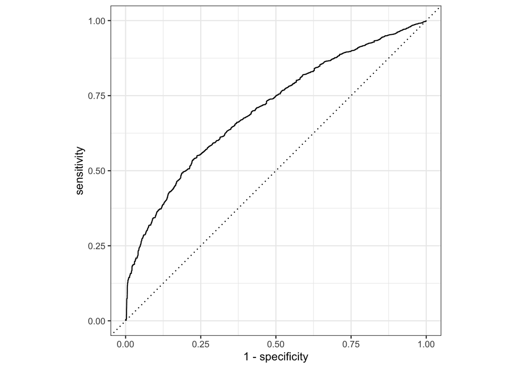

```r
train_roc_auc = roc_curve(train_predict2, habitat, .pred_0)
autoplot(train_roc_auc)
```

```r
test_predict = predict(train_fit, test) %>% #get prediction probabilities for test
  bind_cols(test) #bind to testing column

test_predict2 = predict(train_fit, test, type = "prob") %>% #get testing prediction
  bind_cols(test) #bind to testing column
```

```r
accuracy(test_predict, truth = habitat, estimate = .pred_class) #get accuracy of testing prediction
```

```
## # A tibble: 1 × 3
##   .metric  .estimator .estimate
##   <chr>    <chr>          <dbl>
## 1 accuracy binary         0.672
```

```r
sensitivity(test_predict, truth = habitat, estimate = .pred_class)
```

```
## # A tibble: 1 × 3
##   .metric     .estimator .estimate
##   <chr>       <chr>          <dbl>
## 1 sensitivity binary         0.850
```

```r
specificity(test_predict, truth = habitat, estimate = .pred_class)
```

```
## # A tibble: 1 × 3
##   .metric     .estimator .estimate
##   <chr>       <chr>          <dbl>
## 1 specificity binary         0.357
```

```r
test_roc_auc = roc_curve(test_predict2, habitat, .pred_0)
```

#### Visualizations

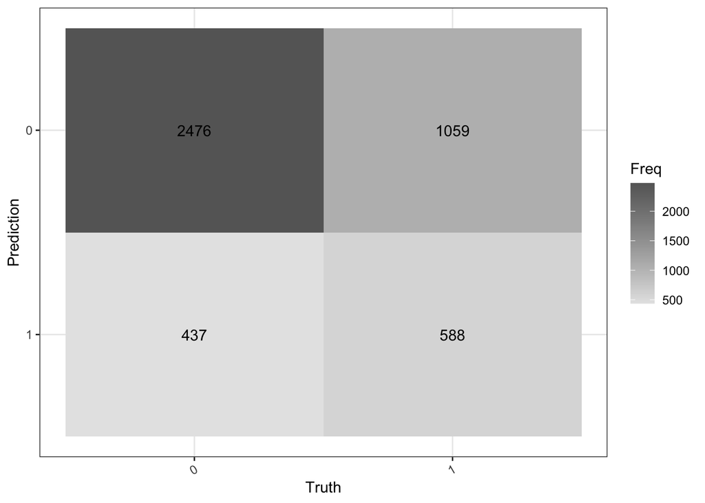

```r
test_predict %>%
  conf_mat(truth = habitat, estimate = .pred_class) %>% #create confusion matrix
  autoplot(type = "heatmap") + #plot confusion matrix with heatmap
  theme_bw() + #change theme
  theme(axis.text.x = element_text(angle = 30, hjust=1)) #rotate axis labels
```

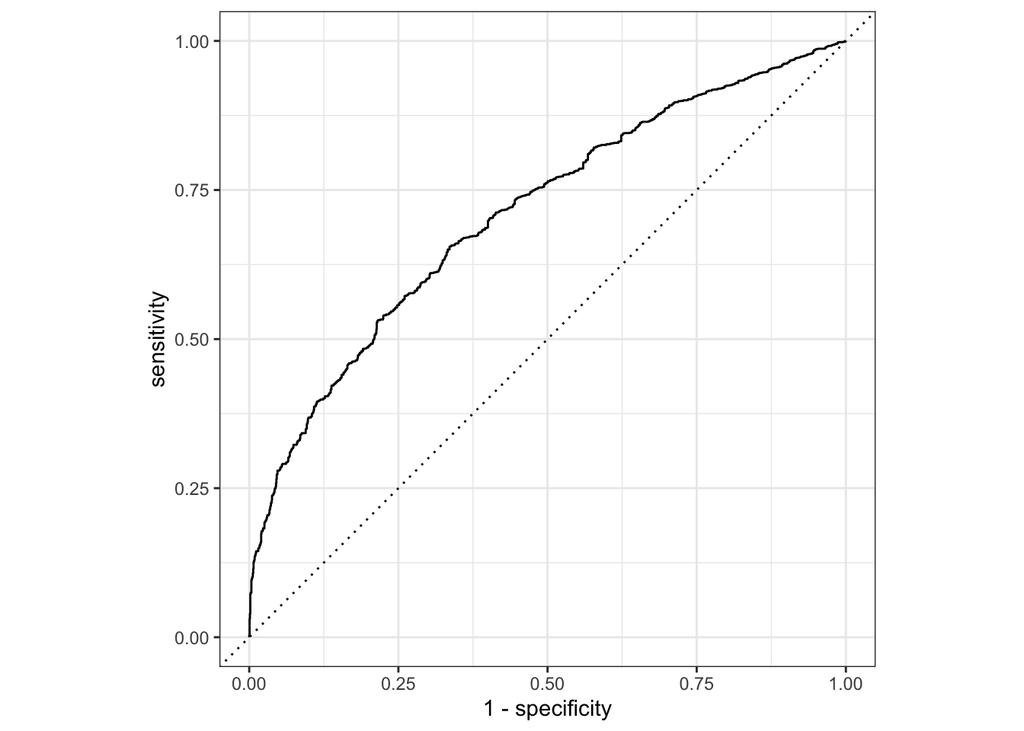

```r
autoplot(test_roc_auc)
```